# RNA-seq Mouse Placenta

Ha T. H. Vu

Documentation for the analysis of mouse placental RNA-seq data at e7.5, e8.5 and e9.5.

## 1. PlacentaCellEnrich

We use the PlacentaCellEnrich (PCE) tool to annotate timepoint-specific genes with placental cell types. The following code was adapted from the R package `TissueEnrich` to carry out PCE analysis. Load the necessary files and define the following function for the analysis.

```r
library(TissueEnrich)
```

```r
library(ggplot2)

load(file = "Files/combine-test-expression1.Rdata")

mouseHumanOrthologs<-dataset$GRCH38$mouseHumanOrthologs
humanGeneMapping<-dataset$GRCH38$humanGeneMapping

#For VentoTormo Data
d <- dataset$PlacentaDeciduaBloodData
data <- d$expressionData
cellDetails <- d$cellDetails
organism <- "Mouse"

runPCE <- function(inputGenes, nameType = c("Gene.name", "Gene.stable.ID")) {
  if (nameType == "Gene.name") {
    humanOrthologs <- mouseHumanOrthologs[mouseHumanOrthologs$Gene.name %in% toupper(inputGenes),]
  } else {
    humanOrthologs <- mouseHumanOrthologs[mouseHumanOrthologs$Gene.stable.ID %in% inputGenes,]
  }
  inputGenes <- humanOrthologs$Human.gene.stable.ID
  expressionData <- data[intersect(row.names(data), mouseHumanOrthologs$Human.gene.stable.ID),]
  se <- SummarizedExperiment(assays = SimpleList(as.matrix(expressionData)), rowData = row.names(expressionData), colData = colnames(expressionData))
  cellSpecificGenesExp <- teGeneRetrieval(se, expressedGeneThreshold = 1)
  print(paste("Number of input genes found is", length(inputGenes)))
  gs <- GeneSet(geneIds=toupper(inputGenes))
  output2 <- teEnrichmentCustom(gs, cellSpecificGenesExp)
  enrichmentOutput <- setNames(data.frame(assay(output2[[1]]), row.names = rowData(output2[[1]])[,1]), colData(output2[[1]])[,1])
  row.names(cellDetails) <- cellDetails$RName
  enrichmentOutput$Tissue <- cellDetails[row.names(enrichmentOutput), "CellName"]

  return(enrichmentOutput)
}

plotPCE <- function(enrichmentOutput, networkName) {
  p <- ggplot(enrichmentOutput,aes(x=reorder(Tissue,-Log10PValue),y=Log10PValue,
                                 label = Tissue.Specific.Genes, fill=Tissue))+
  geom_bar(stat = 'identity')+
    labs(x='', y = '-LOG10(Adj. P-Value)')+
    theme_bw()+
    theme(legend.position='none', plot.margin=unit(c(1,1,1,1),"cm"))+
    theme(plot.title = element_text(hjust = 0.5,size = 20),axis.title =
            element_text(size=15))+
    theme(axis.text.x = element_text(angle = 90, vjust = 1, hjust = 1),
          panel.grid.major= element_blank(),panel.grid.minor = element_blank())+
    ggtitle(networkName)

  return(p)
}
```

First, we do cell annotations with timepoint-specific gene groups.

```
#> [1] "Number of input genes found is 772"
```

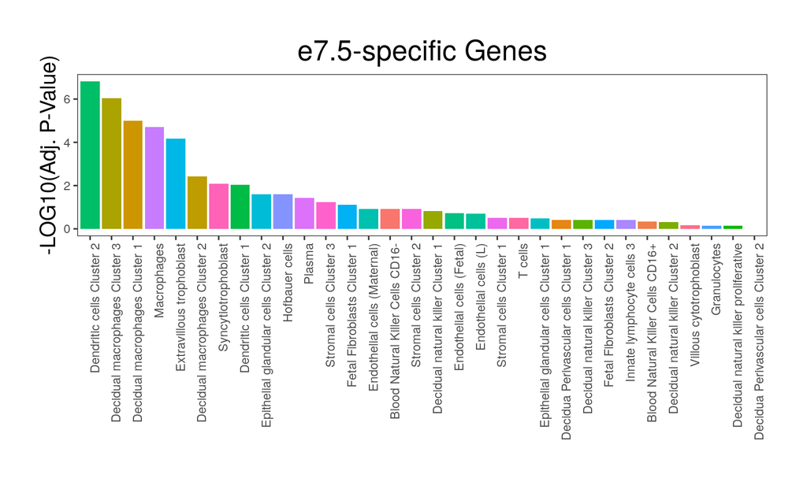

```
#> [1] "Number of input genes found is 827"
```

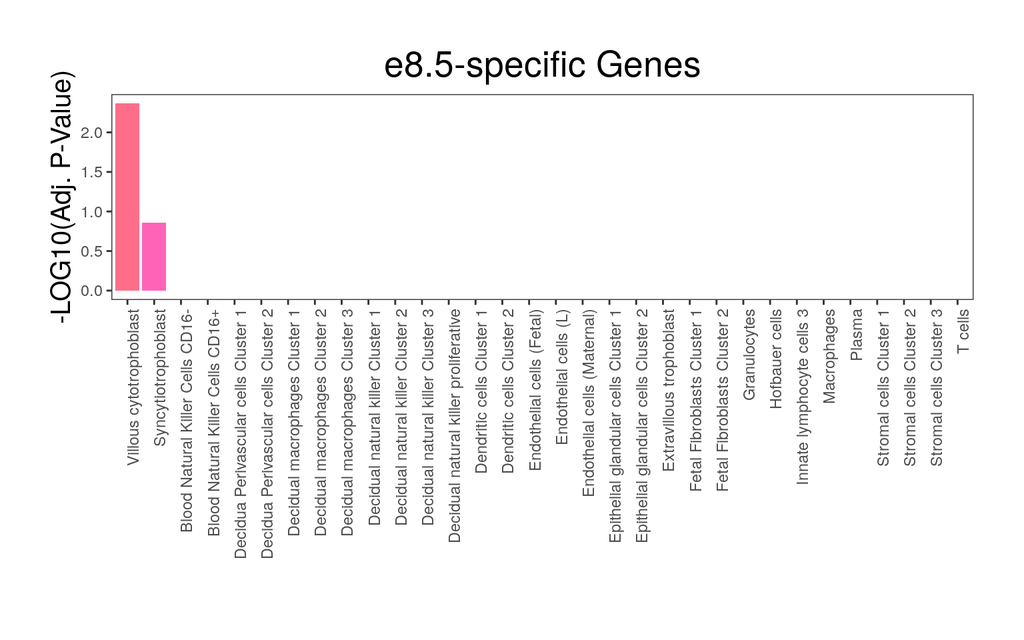

```
#> [1] "Number of input genes found is 1765"
```

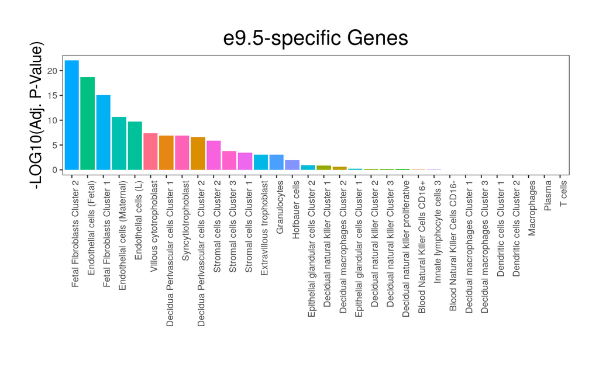

```r
for (time in c("e7.5", "e8.5", "e9.5")) {
  file <- read.table(paste0("Files/", time, "specific_ensGenes.txt"), header = F)
  inputGenes <- file$V1
  enrichmentOutput <- runPCE(inputGenes, "Gene.stable.ID")
  print(plotPCE(enrichmentOutput, paste0(time, "-specific Genes")))
}
```

Next, we do cell annotations with subnetworks obtained from the previous step. Since this step can be repetitive, we first write a function to load the input genes, then analyze.

```r
loadInput <- function(type = c("STRING", "GENIE3"), time = c("e7.5", "e8.5", "e9.5"), i) {
  if (type == "STRING") {
    file <- read.table(paste0("Files/", type, "/", time, "/largestComponent/", time, "_", i, "/", time, "_", i, "_nodeTable.csv"), sep = ",", header = T)
  } else {
    file <- read.table(paste0("Files/", type, "/", time, "/", time, "_", i, "/", time, "_", i, "_nodeTable.csv"), sep = ",", header = T)
  }
  inputGenes <- file$name

  return(inputGenes)
}
```

Analysis for STRING subnetworks:

```
#> [1] "Number of input genes found is 90"
```

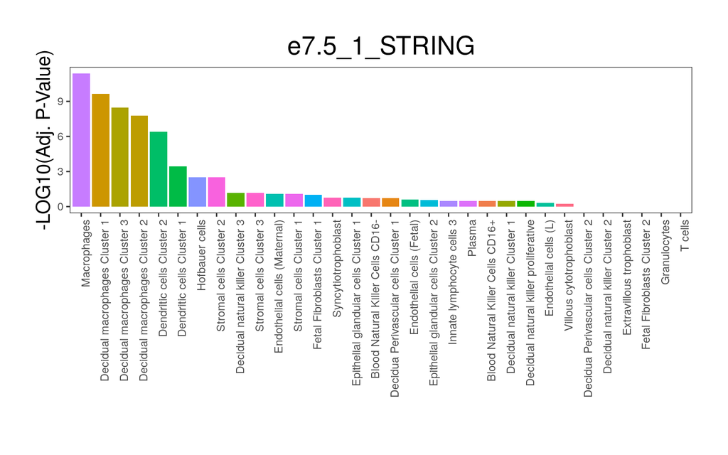

```
#> [1] "Number of input genes found is 173"
```

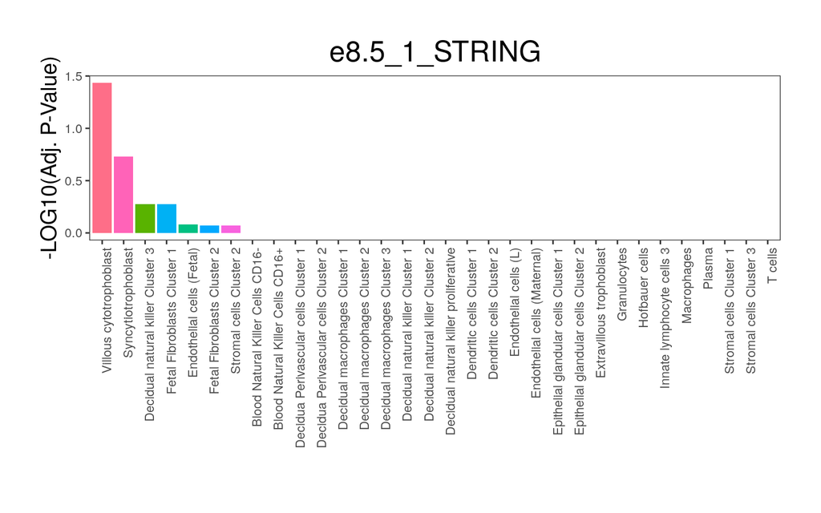

```
#> [1] "Number of input genes found is 242"
```

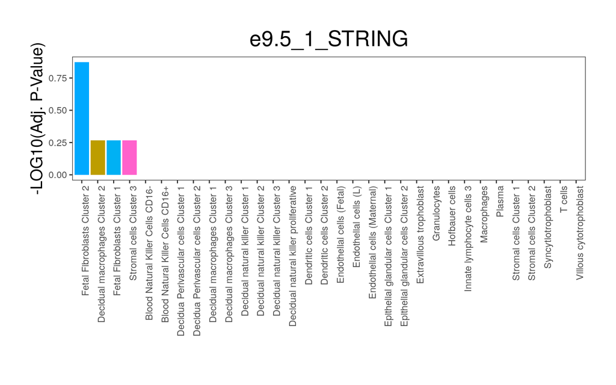

```
#> [1] "Number of input genes found is 230"
```

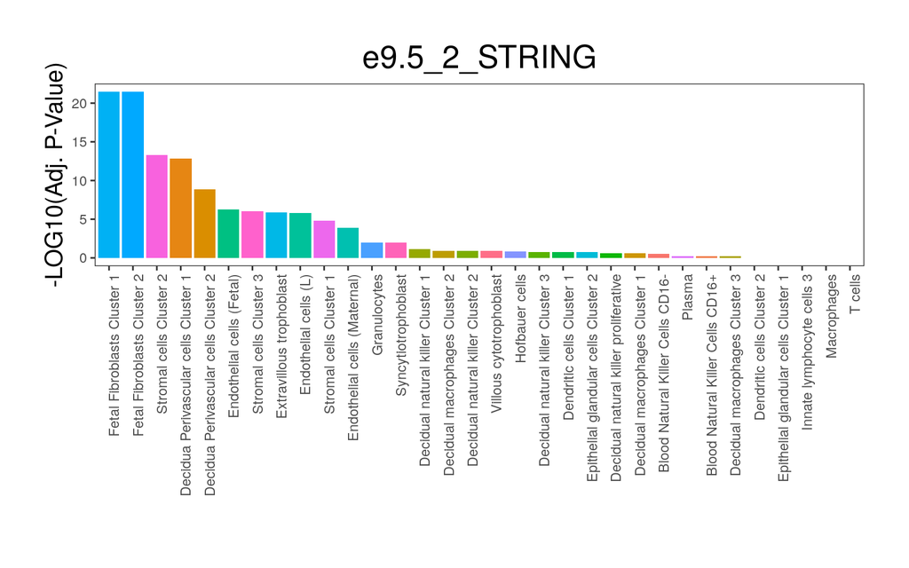

```
#> [1] "Number of input genes found is 180"
```

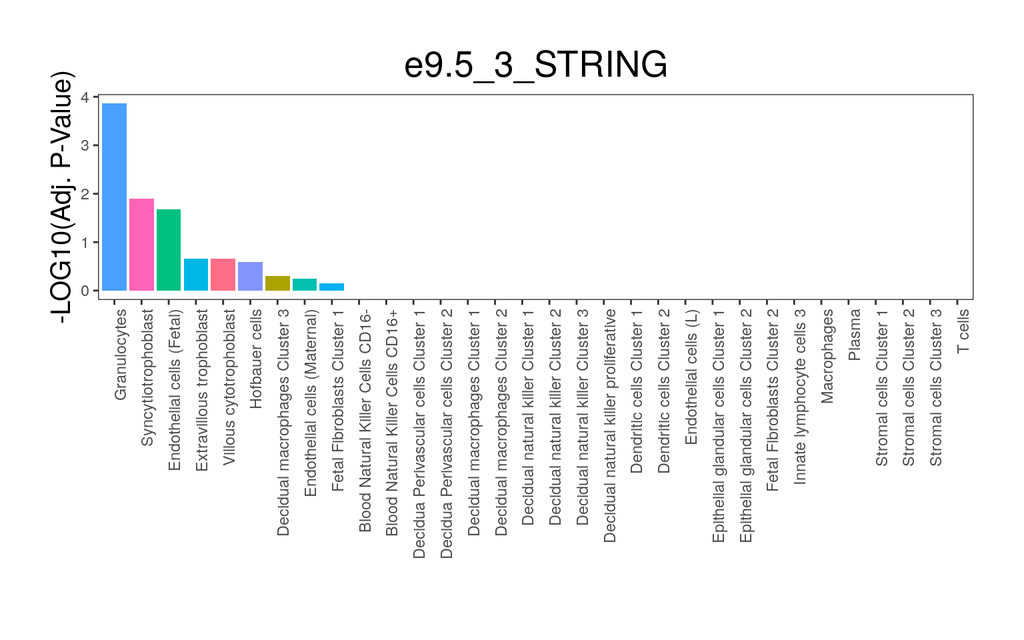

```
#> [1] "Number of input genes found is 182"
```

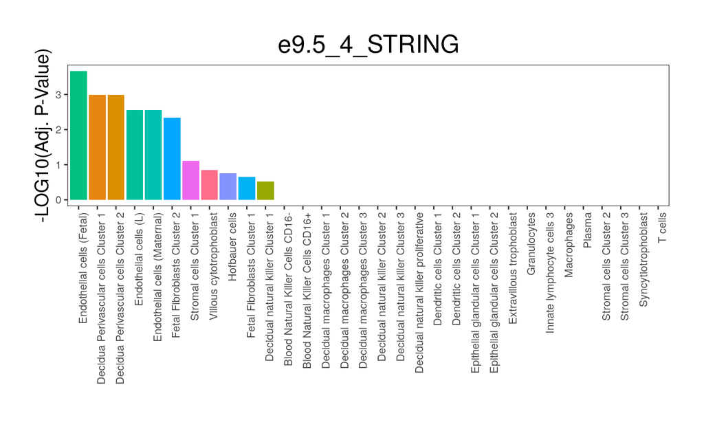

```r
type <- "STRING"
for (time in c("e7.5", "e8.5", "e9.5")) {
  opt <- "Gene.name"
  if (time %in% c("e7.5", "e8.5")) {
    inputGenes <- loadInput(type, time, 1)
    name <- paste0(time, "_", 1, "_", type)
    enrichmentOutput <- runPCE(inputGenes, opt)
    print(plotPCE(enrichmentOutput, name))
  } else {
    for (i in 1:4) {
      inputGenes <- loadInput(type, time, i)
      name <- paste0(time, "_", i, "_", type)
      enrichmentOutput <- runPCE(inputGenes, opt)
      print(plotPCE(enrichmentOutput, name))
    }
  }
}
```

Analysis for GENIE3 subnetworks:

```
#> [1] "Number of input genes found is 183"
```

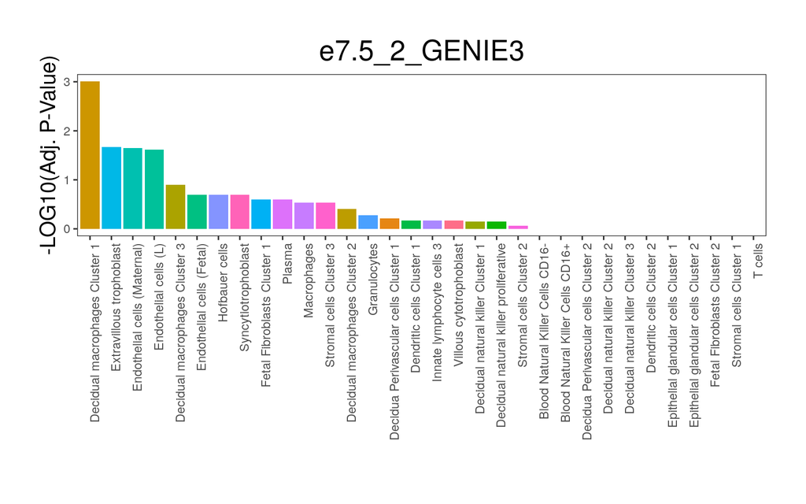

```
#> [1] "Number of input genes found is 202"
```

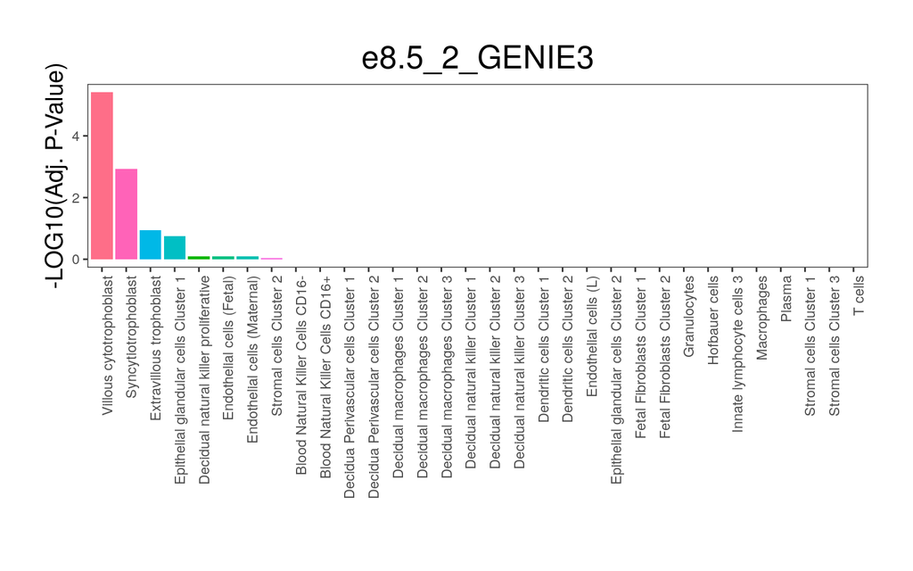

```
#> [1] "Number of input genes found is 376"
```

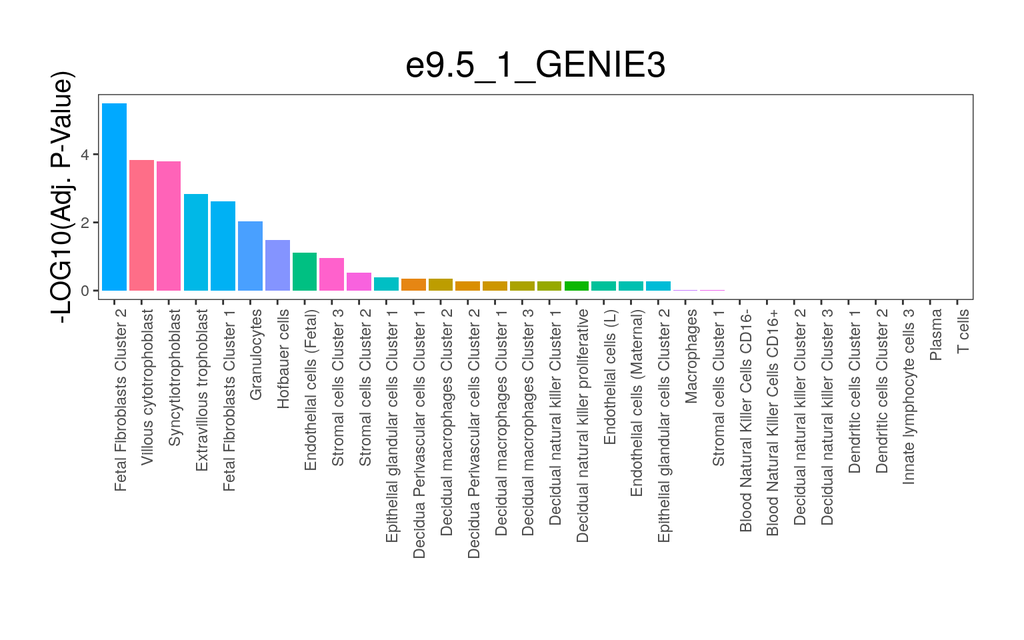

```
#> [1] "Number of input genes found is 322"
```

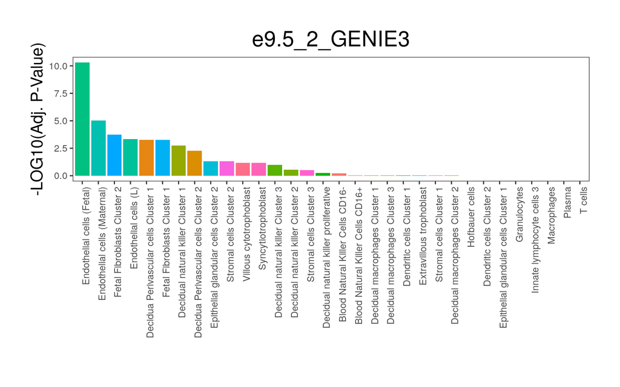

```
#> [1] "Number of input genes found is 312"
```

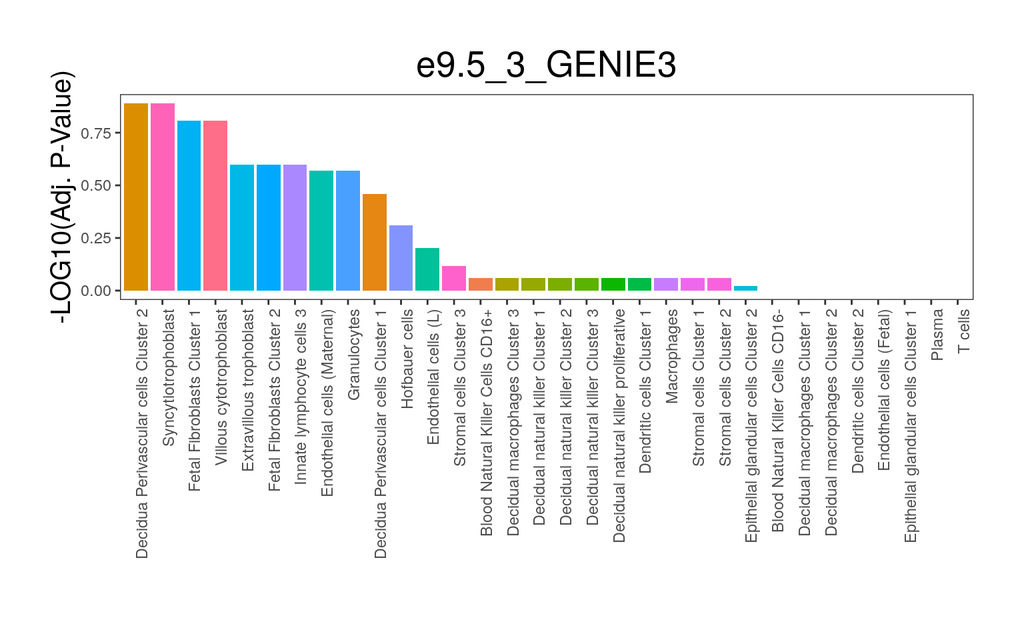

```r
type <- "GENIE3"
for (time in c("e7.5", "e8.5", "e9.5")) {
  opt <- "Gene.stable.ID"
  if (time %in% c("e7.5", "e8.5")) {
    inputGenes <- loadInput(type, time, 2)
    name <- paste0(time, "_", 2, "_", type)
    enrichmentOutput <- runPCE(inputGenes, opt)
    print(plotPCE(enrichmentOutput, name))
  } else {
    for (i in 1:3) {
      inputGenes <- loadInput(type, time, i)
      name <- paste0(time, "_", i, "_", type)
      enrichmentOutput <- runPCE(inputGenes, opt)
      print(plotPCE(enrichmentOutput, name))
    }
  }
}
```

Randomization test:

```r
#!/usr/bin/env Rscript
args = commandArgs(trailingOnly=TRUE)

library("doParallel")

load(file = "Files/combine-test-expression1.Rdata")

mouseHumanOrthologs<-dataset$GRCH38$mouseHumanOrthologs
humanGeneMapping<-dataset$GRCH38$humanGeneMapping

#For VentoTormo Data
d <- dataset$PlacentaDeciduaBloodData
data <- d$expressionData
cellDetails <- d$cellDetails
organism <- "Mouse"

runPCE <- function(inputGenes, nameType = c("Gene.name", "Gene.stable.ID")) {
  if (nameType == "Gene.name") {
    humanOrthologs <- mouseHumanOrthologs[mouseHumanOrthologs$Gene.name %in% toupper(inputGenes),]
  } else {
    humanOrthologs <- mouseHumanOrthologs[mouseHumanOrthologs$Gene.stable.ID %in% inputGenes,]
  }
  inputGenes <- humanOrthologs$Human.gene.stable.ID
  expressionData <- data[intersect(row.names(data), mouseHumanOrthologs$Human.gene.stable.ID),]
  se <- SummarizedExperiment(assays = SimpleList(as.matrix(expressionData)), rowData = row.names(expressionData), colData = colnames(expressionData))
  cellSpecificGenesExp <- teGeneRetrieval(se, expressedGeneThreshold = 1)
  print(paste("Number of input genes found is", length(inputGenes)))
  gs <- GeneSet(geneIds=toupper(inputGenes))
  output2 <- teEnrichmentCustom(gs, cellSpecificGenesExp)
  enrichmentOutput <- setNames(data.frame(assay(output2[[1]]), row.names = rowData(output2[[1]])[,1]), colData(output2[[1]])[,1])
  row.names(cellDetails) <- cellDetails$RName
  enrichmentOutput$Tissue <- cellDetails[row.names(enrichmentOutput), "CellName"]

  return(enrichmentOutput)
}


randFunc <- function(pop, size, cell, i) {
  library("TissueEnrich", suppressMessages())

  gene_set <- sample(pop, size)
  res <- runPCE(inputGenes=gene_set, nameType="Gene.stable.ID")
  if (cell %in% res$Tissue) {
    p <- res[res$Tissue == cell, "Log10PValue"]
  } else {
    p <- 1
  }

  print(i)
  return(p)
}

pop <- read.table(args[1], header = F)
sub <- read.table(args[2], sep = ",", header = T)
no_cores <- 20
cl <- makeCluster(no_cores)
registerDoParallel(cl)
result <- foreach(i=1:10000) %dopar% randFunc(pop$V1, length(sub$name), args[4], i)
stopCluster(cl)

result2 <- unlist(result)
write.table(result2, args[3], row.names = F, sep = "\t", quote = F)
```

## 2. Placenta Ontology

For some networks (`e7.5_1_STRING`, `e9.5_1_STRING`, `e9.5_3_GENIE3`), we do not observe any enrichment for fetal placental cells, possibly because not all genes in the networks are annotated in the background dataset which we used in PCE. Therefore, we also used Placenta Ontology, which carries out enrichment tests based on different background sources than those used in PCE. We obtained placenta ontology GMT file from Naismith et al., 2021 and uploaded the file to the WEB-based GEne SeT AnaLysis Toolkit (www.webgestalt.org) as a functional database. Input gene lists are the human orthologs of our subnetworks.  
We first obtain human orthologs of genes:

```r
type <- "STRING"
for (time in c("e7.5", "e8.5", "e9.5")) {
  if (time %in% c("e7.5", "e8.5")) {
    inputGenes <- loadInput(type, time, 1)
    name <- paste0(time, "_", 1, "_", type)
    humanOrthologs <- mouseHumanOrthologs[mouseHumanOrthologs$Gene.name %in% toupper(inputGenes),]
    write.table(humanOrthologs$Human.gene.name, paste0("Files/PlacentaOntology/", name, ".txt"), quote = F, row.names = F)
  } else {
    for (i in 1:4) {
      inputGenes <- loadInput(type, time, i)
      name <- paste0(time, "_", i, "_", type)
      humanOrthologs <- mouseHumanOrthologs[mouseHumanOrthologs$Gene.name %in% toupper(inputGenes),]
      write.table(humanOrthologs$Human.gene.name, paste0("Files/PlacentaOntology/", name, ".txt"), quote = F, row.names = F)
    }
  }
}
```

```r
type <- "GENIE3"
for (time in c("e7.5", "e8.5", "e9.5")) {
  if (time %in% c("e7.5", "e8.5")) {
    inputGenes <- loadInput(type, time, 2)
    name <- paste0(time, "_", 2, "_", type)
    humanOrthologs <- mouseHumanOrthologs[mouseHumanOrthologs$Gene.stable.ID %in% inputGenes,]
    write.table(humanOrthologs$Human.gene.name, paste0("Files/PlacentaOntology/", name, ".txt"), quote = F, row.names = F)
  } else {
    for (i in 1:3) {
      inputGenes <- loadInput(type, time, i)
      name <- paste0(time, "_", i, "_", type)
      humanOrthologs <- mouseHumanOrthologs[mouseHumanOrthologs$Gene.stable.ID %in% inputGenes,]
      write.table(humanOrthologs$Human.gene.name, paste0("Files/PlacentaOntology/", name, ".txt"), quote = F, row.names = F)
    }
  }
}
```

Delete header in the gene name files so we can upload the files to WebGestal.

```bash
cd Files/PlacentaOntology
for i in *; do tail -n +2 $i > temp; mv temp $i; done
```

After obtaining the results of Placenta Ontology, load them here to plot. We will show results of `e7.5_1_STRING`, `e9.5_1_STRING`, `e9.5_3_GENIE3` here.

```r
plotPO <- function(poResults, networkName) {
  p <- ggplot(poResults,aes(x=reorder(geneSet,-log10(FDR)),y=-log10(FDR),
                                 label = geneSet, fill=geneSet))+
  geom_bar(stat = 'identity')+
    labs(x='', y = '-LOG10(FDR)')+
    theme_bw()+
    theme(legend.position='none')+
    theme(plot.title = element_text(hjust = 0.5, size = 20),axis.title =
            element_text(size=15))+
    theme(panel.grid.major= element_blank(),panel.grid.minor = element_blank())+
    coord_flip()+
    ggtitle(networkName)

  return(p)
}
```

```r
l <- list.files(path = "Files/PlacentaOntology/", pattern = "results")
for (i in l) {
  f <- read.table(paste0("Files/PlacentaOntology/", i), header = T, sep = "\t")
  print(plotPO(f, gsub("_results.txt", "", i)))
}
```

This code is to plot every network’s results.

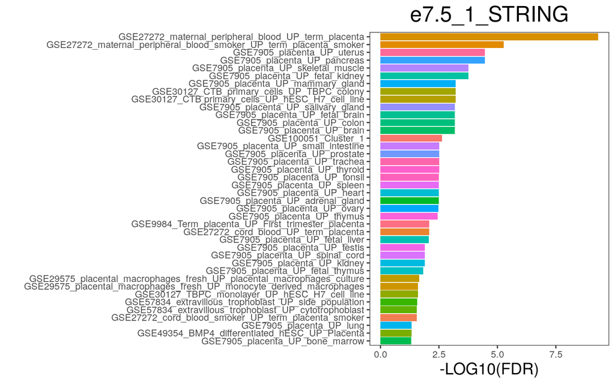

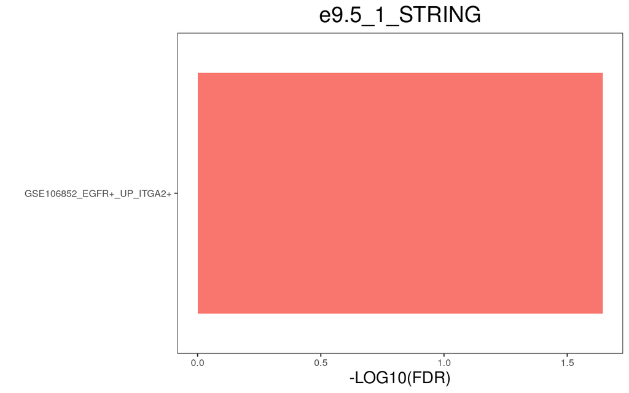

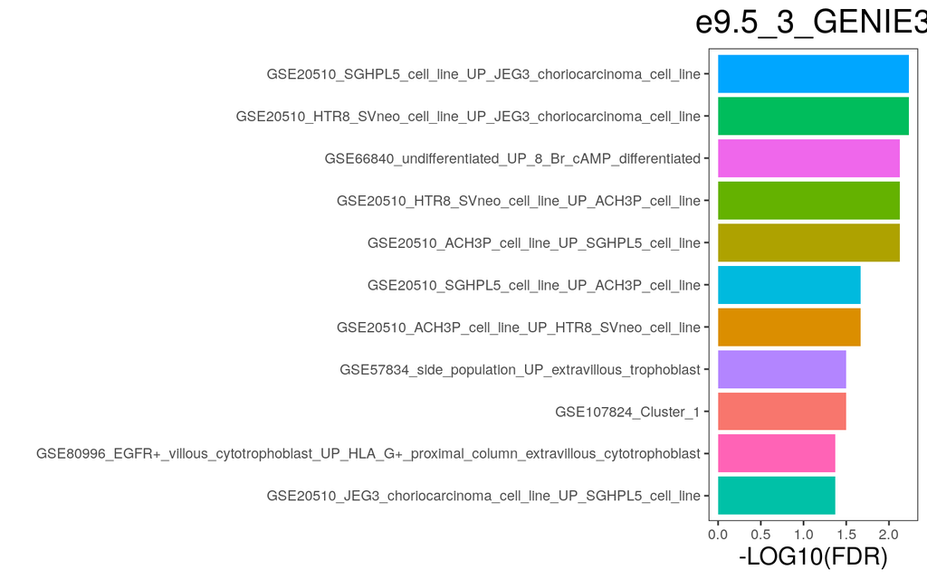

```r
for (i in c("e7.5_1_STRING_results.txt", "e9.5_1_STRING_results.txt", "e9.5_3_GENIE3_results.txt")) {
  f <- read.table(paste0("Files/PlacentaOntology/", i), header = T, sep = "\t")
  print(plotPO(f, gsub("_results.txt", "", i)))
}
```